# IODS course project

### Summary measure analysis of longitudinal data (weight)

```r
# Number of subjects (per group):
n <- 16

library(dplyr)
library(tidyr)
# Summary data with mean and standard error of Weight by group and time
#install.packages("plotrix") #needed for std.error function
library("plotrix")

RATSS <- RATSL %>%
  group_by(Group, Time) %>%
  summarise( mean = mean(Weight), se = std.error(Weight)) %>%
  ungroup()
# Glimpse the data
glimpse(RATSS)
```

```
## Rows: 33
## Columns: 4
## $ Group <fct> 1, 1, 1, 1, 1, 1, 1, 1, 1, 1, 1, 2, 2, 2, 2, 2, 2, 2, 2, 2, 2, 2…
## $ Time  <dbl> 1, 8, 15, 22, 29, 36, 43, 44, 50, 57, 64, 1, 8, 15, 22, 29, 36, …
## $ mean  <dbl> 250.625, 255.000, 254.375, 261.875, 264.625, 265.000, 267.375, 2…
## $ se    <dbl> 5.381640, 4.629100, 4.057346, 4.808614, 3.909409, 4.166190, 3.87…
```

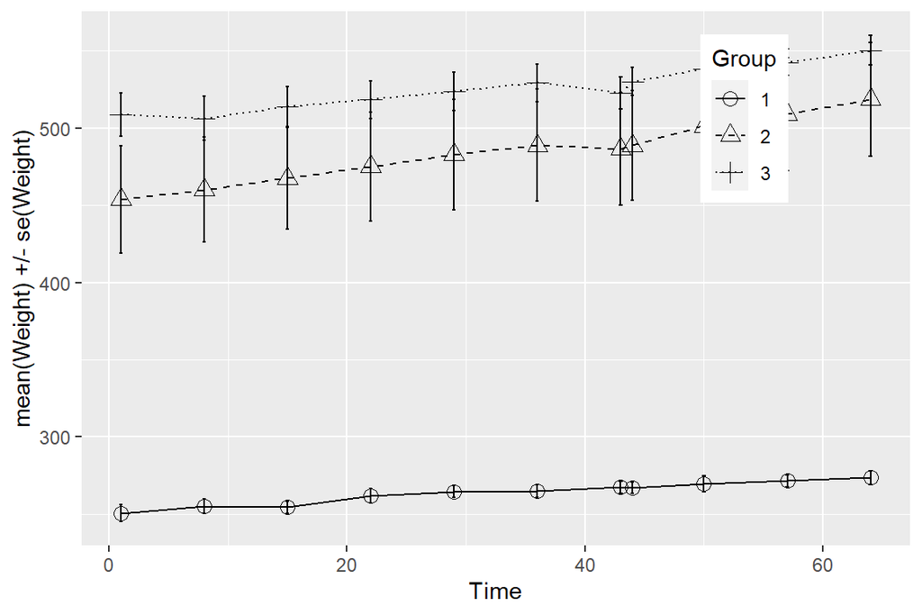

```r
# Plot the mean profiles
library(ggplot2)
ggplot(RATSS, aes(x = Time, y = mean, linetype = Group, shape = Group)) +
  geom_line() +
  scale_linetype_manual(values = c(1:3)) +
  geom_point(size=3) +
  scale_shape_manual(values = c(1:3)) +
  geom_errorbar(aes(ymin=mean-se, ymax=mean+se, linetype="1"), width=0.3) +
  theme(legend.position = c(0.8,0.8)) +
  scale_y_continuous(name = "mean(Weight) +/- se(Weight)")
```

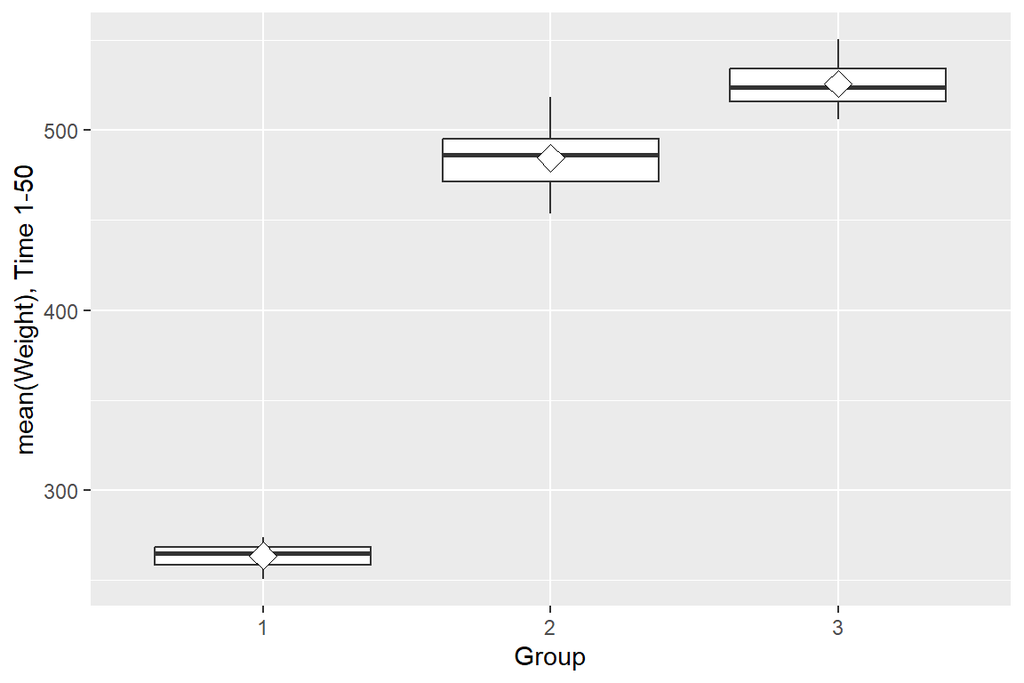

```r
# Draw a boxplot of the mean versus Group
library(ggplot2)
ggplot(RATSS, aes(x = Group, y = mean)) +
  geom_boxplot() +
  stat_summary(fun = "mean", geom = "point", shape=23, size=4, fill = "white") +
  scale_y_continuous(name = "mean(Weight), Time 1-50")
```

```r
#Here we still create a summary data by  Group and ID where baseline (Time=1) is filtered out.
RATSLF <- RATSL %>%
  filter(Time > 1) %>%
  group_by(Group, ID) %>%
  summarise( mean=mean(Weight) ) %>%
  ungroup()
```

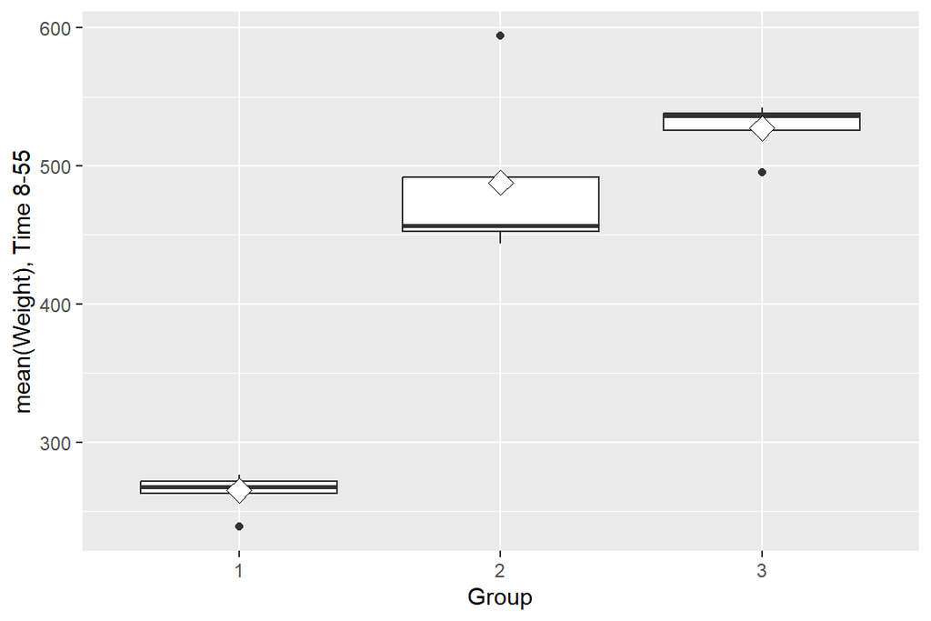

```r
#plotting the filtered data
library(ggplot2)
ggplot(RATSLF, aes(x = Group, y = mean)) +
  geom_boxplot() +
  stat_summary(fun = "mean", geom = "point", shape=23, size=4, fill = "white") +
  scale_y_continuous(name = "mean(Weight), Time 8-55")
```

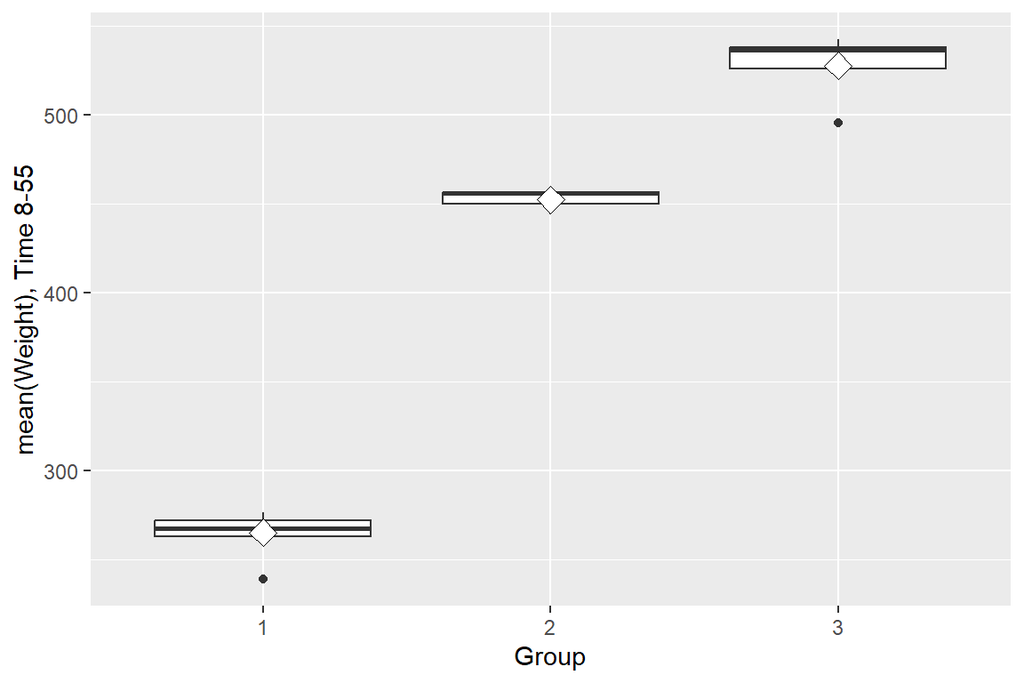

```r
# Create a new data by filtering the outlier we saw in group two and adjust the ggplot code the draw the plot once again
RATSL_ <- RATSLF %>% filter(mean < 550)

ggplot(RATSL_, aes(x = Group, y = mean)) +
  geom_boxplot() +
  stat_summary(fun = "mean", geom = "point", shape=23, size=4, fill = "white") +
  scale_y_continuous(name = "mean(Weight), Time 8-55")
```

It has been argued that the average response to treatment over time is often likely to be the most relevant summary statistic in treatment trials. This is why weight (=the response) was chosen as the summary measure. The groups differ from each others since their mean Weights and their standard errors are not on top of one another on this boxplot. Especially group 1 locates far away from groups 2-3 and seems to differ significantly.

No outliers were found in the boxplot when Time point 1 is included. When the Time point 1 was chosen as baseline and exlcuded from the summary data, we can see an outlier in every group. Only the outlier of group 2 was eventually excluded because it stood out so strongly and the others were included in this analysis.

### Summary measure analysis (for the growth variable)

Since there seem to be rather huge differences in the starting weights between the groups, I decided to test the group differences in percent increase in growth during the follow up time. The variable “growth” was defined already in the data wrangling part (meet_and_repeat.R) from the original longitudinal data RATS by the following equation (RATS$WD64-RATS$WD1)/RATS$WD1.

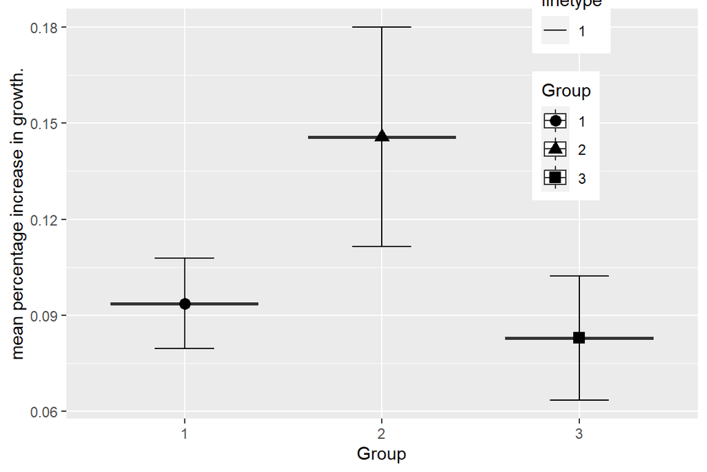

```r
# Number of subjects:
n <- 16

library(dplyr)
library(tidyr)
# Summary data with mean and standard error of Weight by group and time
#install.packages("plotrix") #needed for std.error function
library("plotrix")

RATSSg <- RATSL %>%
 group_by(Group, Time) %>%
  summarise( mean2 = mean(growth), se2 = std.error(growth)) %>%
  ungroup()
# Plot the mean profiles
library(ggplot2)
ggplot(RATSSg, aes(x = Group, y = mean2, shape = Group)) +
  geom_boxplot() +
  geom_point(size=3)  +
  geom_errorbar(aes(ymin=mean2-se2, ymax=mean2+se2, linetype="1"), width=0.3) +
  theme(legend.position = c(0.8,0.8)) +
  scale_y_continuous(name = "mean percentage increase in growth.")
```

### Anova - a formal test for difference

Anova confirms here that the group differences we were able to see in the plots were real. P-values were significant and this means there is significant difference in mean weights between groups. There was also significant difference in group 2 growth as judged by the plottings.

```r
library(dplyr)
library(tidyr)


# Fit the linear model with the mean (weight) as the response
fit <- lm(mean ~  Group, data = RATSL_)
summary(fit)
```

```
##
## Call:
## lm(formula = mean ~ Group, data = RATSL_)
##
## Residuals:
##     Min      1Q  Median      3Q     Max
## -32.300  -2.575   3.400   8.800  14.700
##
## Coefficients:
##             Estimate Std. Error t value Pr(>|t|)
## (Intercept)  265.025      5.086   52.11 1.64e-15 ***
## Group2       187.375      9.738   19.24 2.19e-10 ***
## Group3       262.475      8.809   29.80 1.28e-12 ***
## ---
## Signif. codes:  0 '***' 0.001 '**' 0.01 '*' 0.05 '.' 0.1 ' ' 1
##
## Residual standard error: 14.38 on 12 degrees of freedom
## Multiple R-squared:  0.9882, Adjusted R-squared:  0.9862
## F-statistic: 501.8 on 2 and 12 DF,  p-value: 2.721e-12
```

```r
# Fit the linear model with the  %-growth in weight as the response. First we filter out the  outlier found previously
RATSLG <- RATSL %>% filter(ID != 12)
fit2 <- lm(growth ~  Group, data = RATSLG)
summary(fit2)
```

```
##
## Call:
## lm(formula = growth ~ Group, data = RATSLG)
##
## Residuals:
##       Min        1Q    Median        3Q       Max
## -0.089732 -0.035946  0.004321  0.034168  0.074285
##
## Coefficients:
##              Estimate Std. Error t value Pr(>|t|)
## (Intercept)  0.093638   0.004766  19.647  < 2e-16 ***
## Group2       0.056768   0.009126   6.220 4.07e-09 ***
## Group3      -0.010785   0.008255  -1.306    0.193
## ---
## Signif. codes:  0 '***' 0.001 '**' 0.01 '*' 0.05 '.' 0.1 ' ' 1
##
## Residual standard error: 0.04471 on 162 degrees of freedom
## Multiple R-squared:  0.2352, Adjusted R-squared:  0.2258
## F-statistic: 24.92 on 2 and 162 DF,  p-value: 3.679e-10
```

```r
# Compute the analysis of variance table for the fitted model with anova()
anova(fit)
```

```
## Analysis of Variance Table
##
## Response: mean
##           Df Sum Sq Mean Sq F value    Pr(>F)
## Group      2 207659  103830  501.81 2.721e-12 ***
## Residuals 12   2483     207
## ---
## Signif. codes:  0 '***' 0.001 '**' 0.01 '*' 0.05 '.' 0.1 ' ' 1
```

```r
anova(fit2)
```

```
## Analysis of Variance Table
##
## Response: growth
##            Df  Sum Sq  Mean Sq F value    Pr(>F)
## Group       2 0.09961 0.049803  24.915 3.679e-10 ***
## Residuals 162 0.32382 0.001999
## ---
## Signif. codes:  0 '***' 0.001 '**' 0.01 '*' 0.05 '.' 0.1 ' ' 1
```

```r
View(RATSSg)
View(RATSL)
```